# Exploring the differences between the presidents who get reelected and who not

What indicates a president (trump) get reelected? We know it is highly depend on their performance in the first term. But can we find some clue in their first speech? There might be trival relations. let’s explore the differences bettween those of who got reelected and not.

## install and load the package

```r
packages.used=c(                "dplyr", "tidytext","sentimentr","openNLP","qdap",'ggplot2','reshape','syuzhet','radarchart','tidyr')
# check packages that need to be installed.
packages.needed=setdiff(packages.used,
                        intersect(installed.packages()[,1],
                                  packages.used))
# install additional packages
if(length(packages.needed)>0){
  install.packages(packages.needed, dependencies = TRUE,
                   repos='http://cran.us.r-project.org')
}
library(tm)
library(wordcloud)
library(RColorBrewer)
library(dplyr)
library(tidytext)
library("sentimentr")
library("qdap")
library('ggplot2')
library('reshape')
library('syuzhet')
library(radarchart)
library('tidyr')
```

## Input and process the data

```r
setwd('E:/ads/ADS_Teaching/Projects_startercodes/Project1-RNotebook/data/InauguralSpeeches')
folder.path="./"
speeches=list.files(path = folder.path, pattern = "*.txt")
prex.out=substr(speeches, 6, nchar(speeches)-4)
ff.all<-Corpus(DirSource(folder.path))
ff.allcp=ff.all
ff.all<-tm_map(ff.all, stripWhitespace)
ff.all<-tm_map(ff.all, content_transformer(tolower))
ff.all<-tm_map(ff.all, removeWords, stopwords("english"))
ff.all<-tm_map(ff.all, removeWords, character(0))
ff.all<-tm_map(ff.all, removePunctuation)
ff.all<- tm_map(ff.all, stemDocument, language = "english")
tdm.all<-TermDocumentMatrix(ff.all)
tdm.s <- removeSparseTerms(tdm.all,0.8)
tdf.s <- as.data.frame(as.matrix(tdm.s))
tdf <- as.data.frame(as.matrix(tdm.all))
```

## Speech basic stats: words count, sentences count, avergae words per sentences

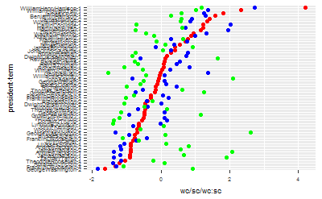

```r
#utils
sentence_count=function(x)
{
seq = sent_detect(x,endmarks = c("?", ".", "!", "|",";"))
return(length(seq))

}
sc=unlist(lapply(ff.allcp,sentence_count))
wc=colSums(tdf)
ra=wc/sc
wordstat=data.frame(sc=scale(sc),wc=scale(wc),ratio=scale(ra))[c(1:58),]
wordstat=wordstat[order(wordstat$wc,wordstat$sc),]
new_name=gsub('inaug','',row.names(wordstat))
new_name=gsub('.txt','',new_name)
row.names(wordstat)=new_name
wordstat$names=factor(row.names(wordstat),levels=row.names(wordstat))
wordstat$term='first without reelected'
wordstat$term[grepl('-2',row.names(wordstat))]='second'
first=wordstat$names[grepl('-2',row.names(wordstat))]
first=paste0(sapply(strsplit(as.character(first),'-'),'[',1),'-1')
wordstat[wordstat$names %in% first,]$term='first with reelected'
wordstat$term=factor(wordstat$term)
ggplot(wordstat, aes( y = names ),fill=c('words','sentences','average words per sentences'))+
   theme(text = element_text(size=7))+
  geom_point(aes(x = wc),color='red') +
  geom_point(aes(x = sc),color='blue')+
  geom_point(aes(x = ratio),color='green')+
  ylab("president-term") + xlab("wc/sc/wc:sc")
```

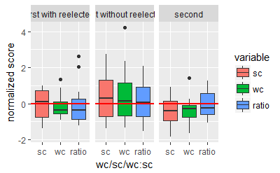

```r
wordstat.m=melt(wordstat, id.vars=c('names','term'))
median.wc=tapply(wordstat$wc,wordstat$term,median)
median.sc=tapply(wordstat$sc,wordstat$term,median)
median.sc=tapply(wordstat$sc,wordstat$term,median)
stats=c('wc','sc','wc/sc')
p2 <- ggplot(wordstat.m, aes(x=variable,y=value,fill=variable))+
  geom_boxplot() +geom_hline(yintercept=0,color = "red", size=1)+facet_wrap(~term)+xlab('wc/sc/wc:sc')+ylab('normalized score')
p2
```

From this grouped box-plot we can clearly see that one-termers talks more than reelected ones, and the reelected ones talk even less in their second term.

Do more talk less, and you might be reelected.

|  | sc | wc | ratio | names | term |
| --- | --- | --- | --- | --- | --- |
| DonaldJTrump-1 | 0.1908843 | -0.5323432 | -1.40004 | DonaldJTrump-1 | first without reelected |

Trump tends to give comparetively shortter sentences and shotter speech. So he might be get reelected according to this criteria. I don’t think this is correct. At least he is too old to get another round.

## Corpus analysis in depth

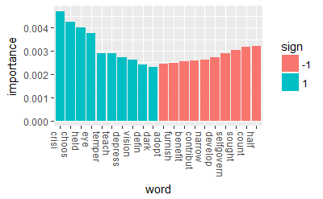

```r
frek=function(x)
{return(x/sum(x))}
extra=function(x) {a=aov(formula = x, data = tdfs1)
vn=strsplit(as.character(x),'~')[2]
return(sign(a$coefficients[2])*summary(a)[[1]][,2][1])}
tdfs1=data.frame(apply(tdf.s,1,frek))
tdfs1=tdfs1[-(c(grep('-2',names(tdf.s)))),]
first=wordstat$names[grepl('-2',row.names(wordstat))]
first=paste0('inaug',sapply(strsplit(as.character(first),'-'),'[',1),'-1')
tdfs1$reelected=0
tdfs1[first,]$reelected=1
#tdfs1$reelected=factor(tdfs1$reelected)
models <- lapply(paste( names(tdfs1),'reelected', sep = "~"), formula)
aov.models <- sapply(models, FUN = extra )
df=data.frame(word=names(tdfs1),importance=aov.models)
df=df[order(-df$importance),]
df$abs=sign(df$importance)*df$importance
df$sign=factor(sign(df$importance))
df$word=factor(df$word,levels=df$word)
ggplot(df[c(1:10,868:877),], aes(x=word,y=abs,fill=sign))+
  geom_bar(stat = "identity" )+ theme(axis.text.x=element_text(angle = -90, hjust = 0))+ylab('importance')
```

Did one way anova of each token towards the target variable (weather reelected or not), find the best 10 that faciliate the reelection and the opposite. The best 10 seems to be more negative and stronger.

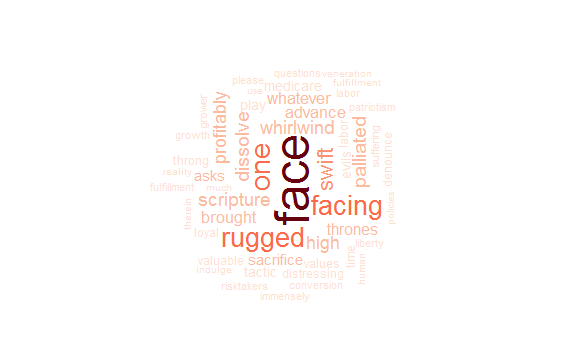

Word Could for those who got reelected.

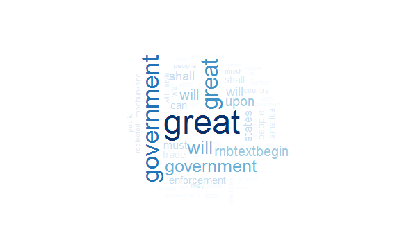

Word Could for those who didn’t get reelected.

## About the word republican

```r
ff.all<-Corpus(DirSource(folder.path))
dat <- data.frame(text=unlist(lapply(ff.allcp,sent_detect)), stringsAsFactors = FALSE)
rep=Search(dat, "republican")
rep[c(25,26,5)]
```

```
[1] "Nothing can be more corrupting, nothing more destructive of all those noble feelings which belong to the character of a devoted republican patriot."
[2] "To this danger to our republican institutions and that created by the influence given to the Executive through the instrumentality of the Federal officers I propose to apply all the remedies which may be at my command."
[3] "We should never be ashamed of the simplicity and prudential economies which are best suited to the operation of a republican form of government and most compatible with the mission of the American people."
```

There are more than 30 sentences mentioned republicans. I randomly picked 3 shorter one. Of cause, we can guess what does these sentences express easily, either critizing their oponents or praise themselves.

[interactive chart not shown]

Here is the raddar plot of average words sentiment score. The emotion blows up when republican get mentioned, which quite accord with our ‘guessing’.

[interactive chart not shown]

```r
setwd('E:/ads/ADS_Teaching/Projects_startercodes/Project1-RNotebook/data/')
```

[output not shown]

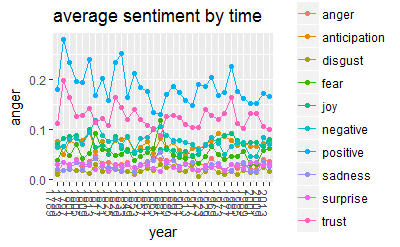

```r
date=read.delim(file='E:/ads/ADS_Teaching/Projects_startercodes/Project1-RNotebook/data/InauguationDates.txt')
names(date)=c('names','1','2','3','4')
date$'1'=sapply(strsplit(as.character(date$'1'),'/'),'[',3)
date$'2'=sapply(strsplit(as.character(date$'2'),'/'),'[',3)
dlong=reshape(date,direction='long',timevar='term',v.names='year',times=c('1','2','3','4'),varying=c('1','2','3','4'))
dlong$term=as.character(dlong$term)
dlong=unite(dlong,'document',sep='-',one_of(c('names','term')))
dlong$document=paste0('inaug',dlong$document,'.txt')
p1=sapply(strsplit(as.character(dlong$document),' '),'[',1)
p2=ifelse(is.na(sapply(strsplit(as.character(dlong$document),' '),'[',3)),sapply(strsplit(as.character(dlong$document),' '),'[',2),sapply(strsplit(as.character(dlong$document),' '),'[',3))
dlong$document=paste0(p1,p2)
wrap=function(x)
{
colSums(get_nrc_sentiment(unique(x$term))*x$count)/sum(x$count)

}
all=merge(dlong,tdm.tidy)
table=ddply(all,.(year),wrap)
ggplot(data=table, aes(x = year,group=1)) +
  geom_point(aes(y=anger,colour='anger'))+
  geom_path(aes(y=anger,colour='anger'))+
  geom_point(aes(y=anticipation,colour='anticipation'))+
  geom_path(aes(y=anticipation,colour='anticipation'))+
  geom_point(aes(y=disgust,colour='disgust'))+
  geom_path(aes(y=disgust,colour='disgust'))+
  geom_point(aes(y=fear,colour='fear'))+
  geom_path(aes(y=fear,colour='fear'))+
  geom_point(aes(y=joy,colour='joy'))+
  geom_path(aes(y=joy,colour='joy'))+
  geom_point(aes(y=sadness,colour='sadness'))+
  geom_path(aes(y=sadness,colour='sadness'))+
  geom_point(aes(y=surprise,colour='surprise'))+
  geom_path(aes(y=surprise,colour='surprise'))+
  geom_point(aes(y=negative,colour='negative'))+
  geom_path(aes(y=negative,colour='negative'))+
  geom_point(aes(y=positive,colour='positive'))+
  geom_path(aes(y=positive,colour='positive'))+
  geom_point(aes(y=trust,colour='trust'))+
  geom_path(aes(y=trust,colour='trust'))+
  theme(axis.text.x=element_text(angle = -90, hjust = 0))+
  ggtitle('average sentiment by time')
```